# Solutions Module 6: Simple Linear Regression

Author

Affiliation

Adam Spiegler

University of Colorado Denver

## Additional Reading

- [Chapter 3 Linear Model Estimation](https://jfrench.github.io/LinearRegression/linear-model-estimation.html) from *A Progressive Introduction to Linear Models*
- Chapter 3 of *Linear Regression Models: Applications in R* ([link to library ebook](https://go.exlibris.link/Q7wgCRrz))
- Chapter 2 of *Applied Linear Regression* ([link to library ebook](https://go.exlibris.link/69jsQwWW))

# Loading Required Packages

```r
library(tidyverse)
library(MASS)
library(plotly)
library(ggfortify)  # for error plots
```

# Case Study: Relation Between Body and Brain Mass of Mammals

The brain mass of a mammal is approximately proportion to the overall body mass of the mammal. Larger mammal species tend to have larger brains than smaller species. Consider the following three mammal species:

- A jaguar has an average body mass of $100$ kg and brain mass of $157$ g.
- A gorilla has an average body mass of $207$ kg and brain mass of $406$ g.
- A horse has an average body mass of $521$ kg and brain mass of $655$ g.

```r
# create data frame
mammal_small <- data.frame("species" = c("Jaguar", "Gorilla", "Horse"),
                      "body" = c(100.0, 207.0, 521.0),
                      "brain" = c(157.0, 406.0, 655.0)
                      )

mammal_small  # display data frame
```

```
  species body brain
1  Jaguar  100   157
2 Gorilla  207   406
3   Horse  521   655
```

## An Initial Model for the Data

Larger mammals typically have larger brains required to perform more complex tasks. Although the relationship between body mass and brain mass is not precisely linear, the relationship can be approximated using a linear model of the form

$$y = \beta \cdot x.$$

We initially assume the vertical intercept is 0 since a mammal that has no body mass would have no brain mass. The model has three ingredients:

- The predictor $x$ is the observed `body` mass (on average), in kg, of the species.
- The response $y$ is the `brain` mass (on average), in g, of the species.
- The coefficient $\beta$ denotes the slope in the linear model.

Below we plot one possible model, $y = 1.5 x$, along with the corresponding errors for each prediction.

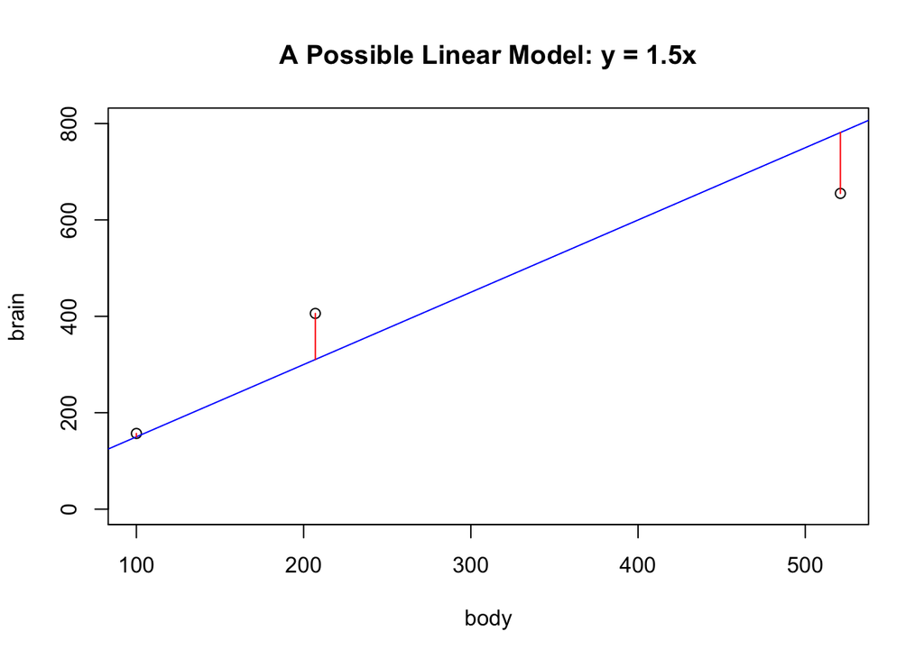

## The Sum of the Squared Errors (SSE)

No model is perfect in the “real-world”, so we should not expect each prediction, denoted $\hat{y}$, to be equal to the observed value, denoted $y$:

$$y = \text{observed brain mass} \qquad \text{compared to} \qquad \hat{y} = \text{prediction} = \beta \cdot x .$$

Which value of $\beta$ gives the “best” model? The **residual** is the observed error between the predicted value $\hat{y}_i = \beta \cdot x_i$ and an observed value at $x_i$, denoted $y_i$:

$$\hat{\epsilon}_i = ( \text{observed} - {\color{blue}{\text{predicted}}}) = (y_i - {\color{blue}{\hat{y}_i}} ) = \big( (y_i - {\color{blue}{\beta \cdot x_i}} ) \big) .$$

- The magnitude of each residual is the length of the vertical line from the observed data point to the line of predictions.
  - If the *error is positive* (observed point is above the line), the prediction is an **underestimate**.
  - If the *error is negative* (observed point is below the line), the prediction is an **overestimate**.
- One common measure of fit is the **sum the squares of the errors** (**SSE**) which is also called the **residual sum of squares** (**RSS**).

For the three species (jaguar, gorilla, and horse) in our data, we have:

| `species` | $x_i$, `body` | $y_i$, `brain` | $\hat{y}_i = \beta x_i$ | $\hat{\epsilon}_i = y_i - \hat{y}_i$ |
| --- | --- | --- | --- | --- |
| Jaguar | $100$ | $157$ | $\beta \cdot 100$ | $(157 - 100\beta)^2$ |
| Gorilla | $207$ | $406$ | $\beta \cdot 207$ | $(406 - 207\beta)^2$ |
| Horse | $521$ | $655$ | $\beta \cdot 521$ | $(655 - 521\beta)^2$ |

Summing together the square of the residuals (in the last column of the table), we obtain a general formula for the sum of the squared errors (SSE) as a function of the slope $\beta$** in our linear model:

$$\text{SSE}(\beta) = (157 - 100\beta)^2 + (406 - 207\beta)^2 + (655 - 521\beta)^2 .$$

Notice the SSE depends only on the value chosen for the slope, $\beta$. One of the most common methods for identifying the line of best fit is using the **ordinary least squares (OLS)** to find the value of the slope, denoted $\hat{\beta}$, that *minimizes the SSE*. We typically express the model of the form $y = \beta x$ that best fits the general formula as

$$\hat{y} = \hat{\beta} x .$$

## Using `lm()` to Find Regression Coefficient

We can use the base R function `lm(y ~ x , data = df)` find OLS estimates for the regression coefficient(s), denoted $\hat{\beta}_0$ and $\hat{\beta}_1$, in a linear regression model of the form $y = \beta_0 + \beta_1 x$. Run `?lm` from the console to learn more.

**Note**

We initially set the intercept $\beta_0 = 0$ and consider a model with one parameter, $y = \beta x$. Thus, we define our model as `brain ~ body + 0`, setting the intercept to $0$. Generally, we include an intercept parameter in our model with the model `brain ~ body`.

```r
# fit linear model y = b x
lmod_small <- lm(brain ~ body + 0, data = mammal_small)
summary(lmod_small)  # display summary
```

```
Call:
lm(formula = brain ~ body + 0, data = mammal_small)

Residuals:
     1      2      3
 21.01 124.50 -53.50

Coefficients:
     Estimate Std. Error t value Pr(>|t|)
body   1.3599     0.1703   7.986   0.0153 *
---
Signif. codes:  0 '***' 0.001 '**' 0.01 '*' 0.05 '.' 0.1 ' ' 1

Residual standard error: 96.97 on 2 degrees of freedom
Multiple R-squared:  0.9696,    Adjusted R-squared:  0.9544
F-statistic: 63.78 on 1 and 2 DF,  p-value: 0.01532
```

The line of best fit is therefore

$${\color{blue}{\hat{y} = 1.36 x}}.$$

### The `summary()` of `lm()`

The `summary` function summarizes the results of our fitted model.

When an `lm` object is supplied to the `summary` function, it returns:

- `Call`: the function call used to fit the model.
- `Residuals`: A 5-number summary of $\hat{\epsilon}_1, \ldots, \hat{\epsilon}_n$.
- `Coefficients`: A table that lists the regression coefficients along with measurements of variance/significance.
- Various summary statistics:
  - `Residual standard error` is the value of standard error of the residuals including the degrees of freedom.
  - `Multiple R-squared` is a measure of model fit.
  - `Adjusted R-squared` is a modified version of `Multiple R-squared`.
  - `F-statistic` is the test statistic of the test that compares the model with a null model (only an intercept term).

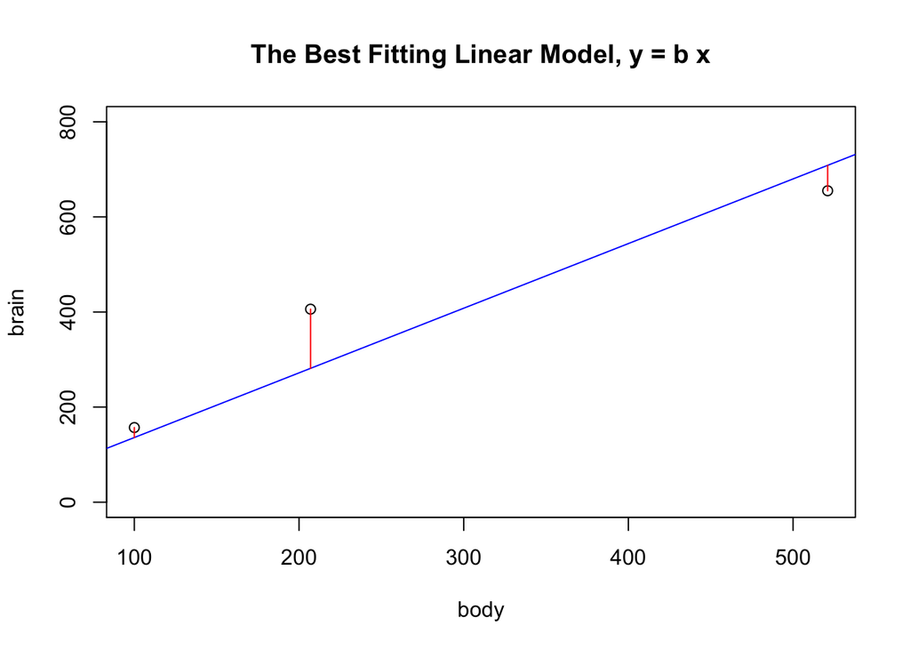

```r
# observed values of x
x <- mammal_small$body  # observed values of x
x
```

```
[1] 100 207 521
```

```r
# compute predicted values y_hat
y_hat <- lmod_small$coefficients[1] * mammal_small$body  # predicted values y = b x
y_hat
```

```
[1] 135.9885 281.4961 708.4999
```

```r
# using output stored to lmod_small
predict(lmod_small)
```

```
       1        2        3
135.9885 281.4961 708.4999
```

```r
# compute residuals
y <- mammal_small$brain
y - y_hat
```

```
[1]  21.01153 124.50387 -53.49991
```

```r
# compute SSE using output stored to lmod_small
residuals(lmod_small)
```

```
        1         2         3
 21.01153 124.50387 -53.49991
```

```r
# using output stored to lmod_small
sum(residuals(lmod_small)^2)
```

```
[1] 18804.94
```

## Finding a Formula for $\hat{\beta}$

Let’s find a general formula for the OLS estimate for $\beta$ in the linear model $y = \beta \cdot x$. In general, we have

$$\text{SSE}(\beta) = \sum_{i=1}^n (y_i - \hat{y}_i )^2 = \sum_{i=1}^n (y_i - \beta \cdot x_i )^2.$$

We find the minimum by setting the derivative equal to $0$ to identify the critical points.

$$\begin{align}
\frac{d}{d{\color{blue}{\beta}}} \big( \text{SSE}({\color{blue}{\beta}}) \big) &= \frac{d}{d{\color{blue}{\beta}}} \bigg( \sum_{i=1}^n (y_i - {\color{blue}{\beta}} \cdot x_i )^2 \bigg) \\
&= \sum_{i=1}^n \bigg( \frac{d}{d{\color{blue}{\beta}}} (y_i - {\color{blue}{\beta}} \cdot x_i )^2 \bigg) \\
&= \sum_{i=1}^n \bigg( -2x_i (y_i - \beta \cdot x_i) \bigg) \\
&= \sum_{i=1}^n (2x^2_i \beta - 2x_iy_i) \\
&= 2 \beta \sum_{i=1}^n {x_i^2} - 2 \sum_{i=1}^n (x_i y_i)
\end{align}.$$

Setting the derivative equal to zero and solve for $\beta$ gives a formula for finding the OLS estimate for the slope that is denoted $\hat{\beta}$,

$$\large{\hat{\beta} = \frac{\sum_{i=1}^n (x_i y_i)}{\sum_{i=1}^n x^2_i} }. \tag{1}$$

```r
# compute beta using calc derived formula
x <- mammal_small$body
y <- mammal_small$brain

beta_hat_small <- sum(x * y) / sum(x^2)
beta_hat_small
```

```
[1] 1.359885
```

This confirms the output from `lm()` stored in `lmod_small`.

## Minimizing the SSE with `optimize()`

```r
x <- mammal_small$body
y <- mammal_small$brain

# define a function for the SSE
sse_small <- function(m) {
  sum( (m * x - y)^2 )
}
```

```r
# compute SSE as a function of beta
sse_small(lmod_small$coefficients[1])
```

```
[1] 18804.94
```

```r
# minimize the SSE
optimize(sse_small, c(0,10), maximum = FALSE)
```

```
$minimum
[1] 1.359885

$objective
[1] 18804.94
```

This is consistent with both the `lm()` and analytic approaches!

# A Larger `mammals` Data Set

The package `MASS` contains the `mammals` data frame which is “a data frame with average brain and body weights for 62 species of land mammals.”

- `body` is the body weight in kg.
- `brain` is the brain weight in g.
- Each row also has a `rowname`, the name of the species.

## Loading the Data

```r
#library(MASS)  # requires MASS package
data(mammals)  # load mammals data
str(mammals)  # look at structure
```

```
'data.frame':   62 obs. of  2 variables:
 $ body : num  3.38 0.48 1.35 465 36.33 ...
 $ brain: num  44.5 15.5 8.1 423 119.5 ...
```

```r
# a peak at the full data
head(mammals)
```

```
                   body brain
Arctic fox        3.385  44.5
Owl monkey        0.480  15.5
Mountain beaver   1.350   8.1
Cow             465.000 423.0
Grey wolf        36.330 119.5
Goat             27.660 115.0
```

## Cleaning the Data

```r
# add variable species, rather than rowname
mammals <- data.frame(species = rownames(mammals),  # species variable
                      body = mammals$body,
                      brain = mammals$brain)

head(mammals)  # print first 6 rows
```

```
          species    body brain
1      Arctic fox   3.385  44.5
2      Owl monkey   0.480  15.5
3 Mountain beaver   1.350   8.1
4             Cow 465.000 423.0
5       Grey wolf  36.330 119.5
6            Goat  27.660 115.0
```

### Inspecting the Data for Outliers

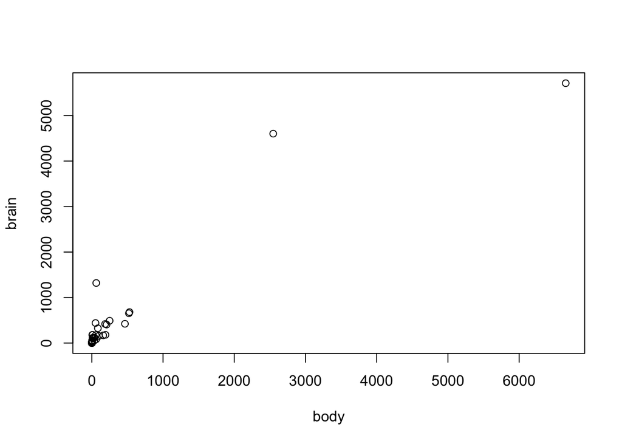

```r
plot(brain ~ body, mammals)
```

## Plotting Data in `mammals_clean`

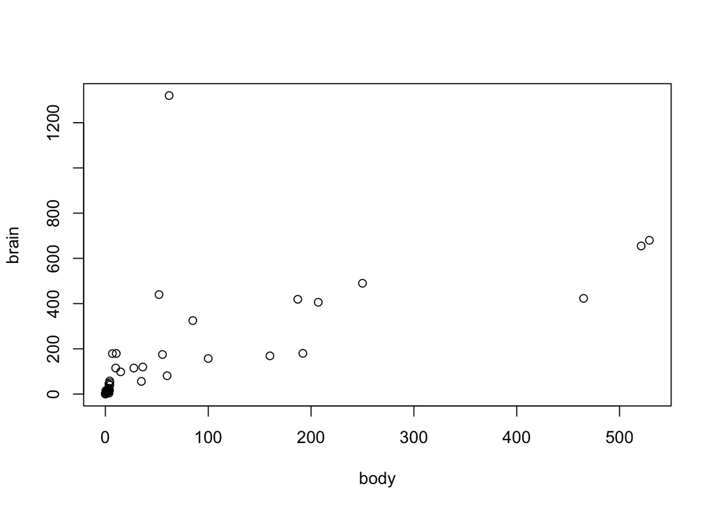

```r
mammals_clean <- filter(mammals, body < 2000)
plot(brain ~ body, mammals_clean)
```

# Model 1: $Y = \beta X$

Let’s first consider using the same linear model as our initial data set of three species. Namely we first assume the vertical intercept is $0$ and consider a linear model with one parameter $y = \beta x$ that we fit to the cleaned `mammals` data.

## Performing Regression with `lm()`

```r
lmod_brain <- lm(brain ~ body + 0, data = mammals_clean)
summary(lmod_brain)
```

```
Call:
lm(formula = brain ~ body + 0, data = mammals_clean)

Residuals:
    Min      1Q  Median      3Q     Max
-235.76    1.27    6.30   40.88 1232.17

Coefficients:
     Estimate Std. Error t value Pr(>|t|)
body   1.4167     0.1804   7.852 9.74e-11 ***
---
Signif. codes:  0 '***' 0.001 '**' 0.01 '*' 0.05 '.' 0.1 ' ' 1

Residual standard error: 180.9 on 59 degrees of freedom
Multiple R-squared:  0.511, Adjusted R-squared:  0.5027
F-statistic: 61.65 on 1 and 59 DF,  p-value: 9.74e-11
```

The linear model is $y = 1.417 x$

## Using the OLS Formula

We can also use equation (1) to quickly find the OLS estimate for $\hat{beta}$.

$$\hat{\beta} = \frac{\sum_{i=1}^n x_i y_i}{\sum_{i=1}^n x^2_i}.$$

```r
x <- mammals_clean$body
y <- mammals_clean$brain
beta_hat <- sum(x * y) / sum(x^2)
beta_hat
```

```
[1] 1.416679
```

# Model 2: Adding an Intercept Term

Next we consider adding an additional parameter into our linear model, the vertical intercept. Thus, we consider a two parameter family:

$$y = \beta_0 + \beta_1 \cdot x$$

## Question 1

Play around with the slope and intercept in the code cell below to find the line of best. Once you think you have an adequate line, compute the SEE to assess the fit.

[figure not shown]

```r
# run to compute corresponding sse
sum( (intercept + slope * mammals_clean$body - mammals_clean$brain)^2 )
```

```
[1] 1783269
```

## Using `lm()` for Linear Model 2

By default, the `lm(y ~ x_1 + x_2 + ... + x_p, data = df)` function returns the coefficients and diagnostics corresponding the linear regression model

$$y = \beta_0 + \beta_1 x_1 + \beta_2 x_2 + \ldots + \beta_p x_p + \epsilon$$

**Note**

By default an intercept term is included in the model which is good since we normally do want to include that term in our linear models.

## Question 2

Use the `lm()` function to find the OLS estimates for the line of best fit. Then enter a formula to compute the corresponding SSE and compare with your results in the previous question.

**Tip**

You do not need to compute the residuals yourself to find the RSS. Instead, you may apply a function to the output of `lm()` to compute the RSS.

### Solution to Question 2

```r
lmod_brain2 <- lm(brain ~ body, data = mammals_clean)
summary(lmod_brain2)
```

```
Call:
lm(formula = brain ~ body, data = mammals_clean)

Residuals:
    Min      1Q  Median      3Q     Max
-210.81  -53.74  -46.76  -14.45 1187.00

Coefficients:
            Estimate Std. Error t value Pr(>|t|)
(Intercept)  55.9519    24.6505   2.270    0.027 *
body          1.2427     0.1905   6.524 1.84e-08 ***
---
Signif. codes:  0 '***' 0.001 '**' 0.01 '*' 0.05 '.' 0.1 ' ' 1

Residual standard error: 174.8 on 58 degrees of freedom
Multiple R-squared:  0.4232,    Adjusted R-squared:  0.4133
F-statistic: 42.56 on 1 and 58 DF,  p-value: 1.84e-08
```

```r
deviance(lmod_brain2)
```

```
[1] 1772288
```

We obtain the linear model $y = 56 + 1.24 x$.

## Using Formulas for OLS Estimates

We have a new SSE function:

$$\text{SSE}(\beta_0, \beta_1) = \sum_{i=1}^n \big( y_i - {\color{blue}{\hat{y}_i}} \big) = \sum_{i=1}^n \big( y_i - ({\color{blue}{\beta_0 + \beta_1 \cdot x_i}}) \big)^2$$

To minimize, we simultaneously solve the equations

$$\left\{ \begin{align}
\frac{\partial}{\partial \beta_0} \bigg( \text{SSE}(\beta_0, \beta_1) \bigg) &= 0\\
\frac{\partial}{\partial \beta_1} \bigg( \text{SSE}(\beta_0, \beta_1) \bigg) &= 0
\end{align} \right.$$

Using multivariable calculus, we can obtain formulas for the OLS estimates:

$$\large{\hat{\beta}_1 = \frac{\sum (x_i - \bar{x})(y_i - \bar{y})}{\sum (x_i - \bar{x})^2}} \qquad \text{and} \qquad \large{\hat{\beta_0} = \bar{y} - \hat{\beta_1} \bar{x}} .$$

```r
x <- mammals_clean$body  # observed x
y <- mammals_clean$brain  # observed y
x_bar <- mean(x)  # sample mean x-bar
y_bar <- mean(y)  # sample mean y-bar

# using formulas above
beta1_hat <- sum( (x - x_bar)*(y - y_bar)) / sum( (x - x_bar)^2 )
beta0_hat <- y_bar - beta1_hat * x_bar

beta1_hat  # estimate for slope
```

```
[1] 1.242713
```

```r
beta0_hat  # estimate for intercept
```

```
[1] 55.95186
```

### Multivariable Optimization with `optim()`

```r
# define sse for y = b_0 + b_1 x
sse_mammal2 <- function(params) {
  b0 <- params[1]
  b1 <- params[2]
  sum( (b0 + b1 * mammals_clean$body - mammals_clean$brain)^2 )
}
```

```r
# use optim to find minimum
my_guess <- c(b0 = 0, b1 = 1)
optim(par = my_guess, fn = sse_mammal2)
```

```
$par
       b0        b1
55.970628  1.242585

$value
[1] 1772288

$counts
function gradient
      93       NA

$convergence
[1] 0

$message
NULL
```

# Adding a Regression Line to a Scatter Plot

## Using `base` R

- We use the `plot(y ~ x, data = df)` function to generate a scatter plot.
- We use the `abline(a, b)` function to add a line of the form $y = a + bx$ to the plot.
  - Regression coefficients are stored in the output of `lmod_brain2`.

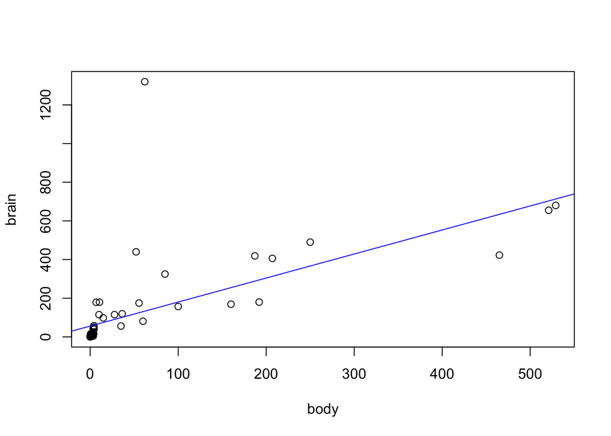

```r
plot(brain ~ body, mammals_clean)
abline(lmod_brain2,
       col = "blue",  # option to change color
       lwt = 2)  # option to make line thicker
```

## Creating an Interactive Plot

```r
ggbrain <- ggplot(mammals_clean, aes(x = body, y = brain)) +
  geom_point(aes(text = species)) +
  geom_smooth(method = "lm") +
  theme_classic()

ggplotly(ggbrain)
```

[interactive chart not shown]